# Stability of QNMs

Last Run 2024-10-08

**Author: M Fisher**

**Date written: 2024-09-23**

# Description

Each QPress simulation runs until it produces 10,000 stable matrices. The object produced by QPress’ `system.simulate` records the total number of matrices produced to reach 10,000 stable ones.

Compare the % total matrices that were stable (**“% stable matrices”**) across operating model scenarios (OMs) x management strategies (HCRs).

Hypothesis: The OMs / HCRs which showed the least agreement between the quantitative MSE and QNMs will have the lowest % matrices that were stable.

## Data

Read in the output from perturbations `system.simulate` output should have been saved as lists from qnm_mse_master.R

```r
s <- Sys.time()


hcrA_out <- readRDS(here('data','qnm_out',paste0('mse0-5_hcrA_10K_',sim.date,'.rds')))
hcrB_out <- readRDS(here('data','qnm_out',paste0('mse0-5_hcrB_10K_',sim.date,'.rds')))
hcrC_out <- readRDS(here('data','qnm_out',paste0('mse0-5_hcrC_10K_',sim.date,'.rds')))
hcrD_out <- readRDS(here('data','qnm_out',paste0('mse0-5_hcrD_10K_',sim.date,'.rds')))
hcrE_out <- readRDS(here('data','qnm_out',paste0('mse0-5_hcrE_10K_',sim.date,'.rds')))

hcr_out_all <- list(hcrA_out,hcrB_out,hcrC_out,hcrD_out,hcrE_out)
names(hcr_out_all) <- c("A","B","C","D","E")


end.timer(s)
```

```
## Time difference of 6.06 secs
```

Read in the counts of mismatched qual v quant results.

```r
compare_df <- read_csv(here('data','results','qnmVmse_mismatches_byOMbyHCR20240923.csv'))
```

Read in the qualitative outcomes from the QNMs, so we can count equivocal results.

## stability & mismatched results

What is the overall distribution of proportion stable matrices?

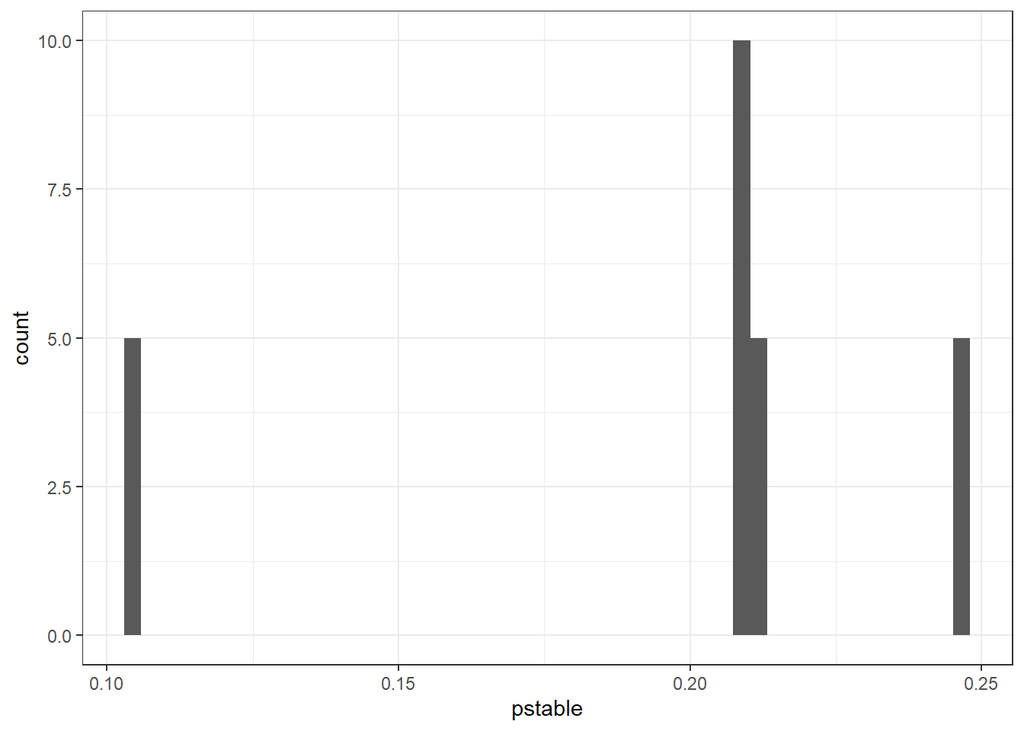

Break down by OM/MS: Is the stability of OM 5 (had the most mismatches between the quantitative MSE and the QNMs)

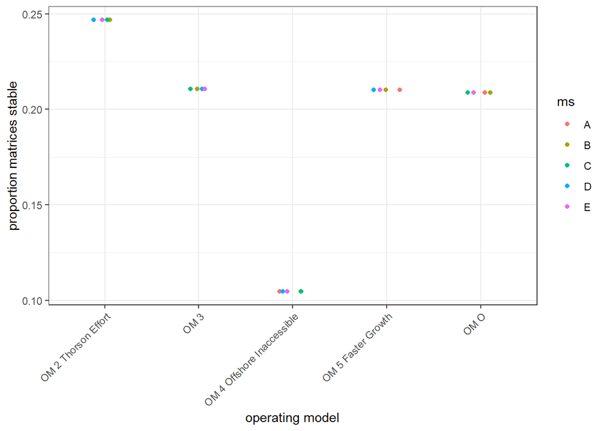

wild! so OM 4 (offshore inaccessible biomass because of climate change) was the least stable, while OM 2 (Thorson effort) was the most stable.

This is not what I expected!

Does % mismatches trend with % stable matrices?

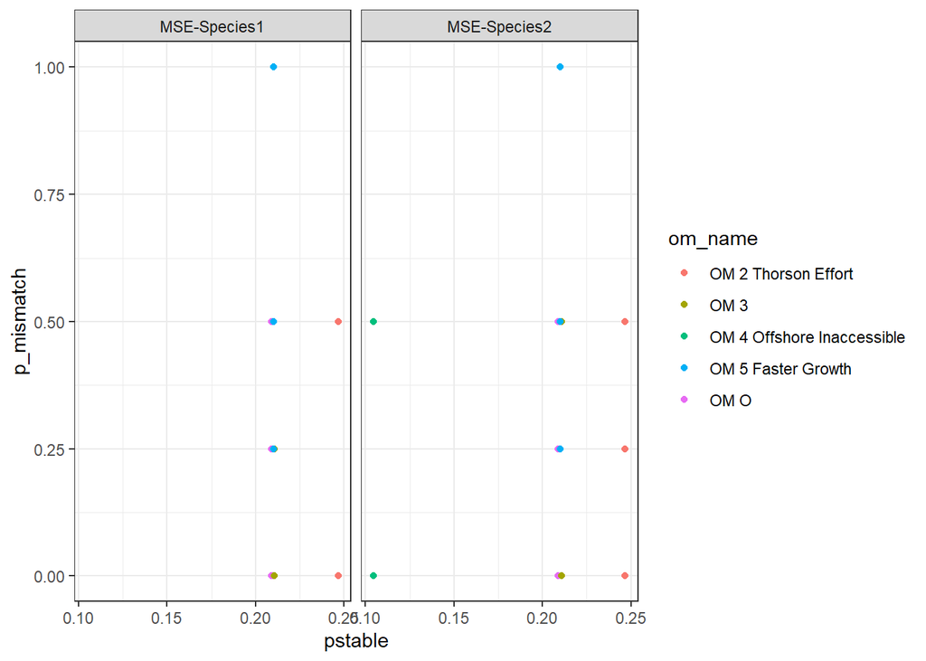

## stability & equivocal QNM output

The OM with the least stability will probably have the most equivocal outcomes for metrics?…

```
## 'n_tot'. You can override using the `.groups` argument.
```

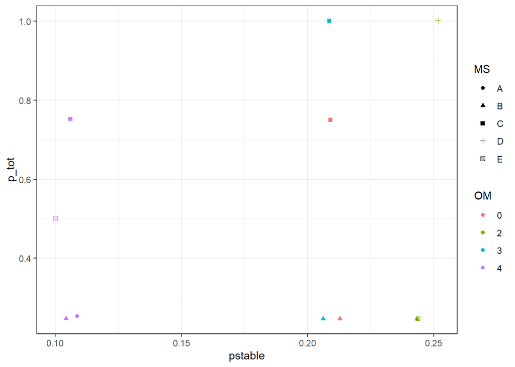

hmm. nope.